# PDO Survey Word Clouds

Last Time of Update (IST) : 2021-10-01 19:18:34

## Readme

### A note

I have only included the open-ended questions in this report. To begin with, we just have the word clouds. This dashboard has both Translated and Raw word clouds. Translation was completed using the google translate API and only the top 200 most frequently words per question were translated using an in-house, smart and cost saving translation mechanism. The raw word clouds have been added for Sharan to look at.

### Changelog

v1 : Added word clouds

# Word Clouds

## What aspect of your job do you find most satisfying?

### Raw

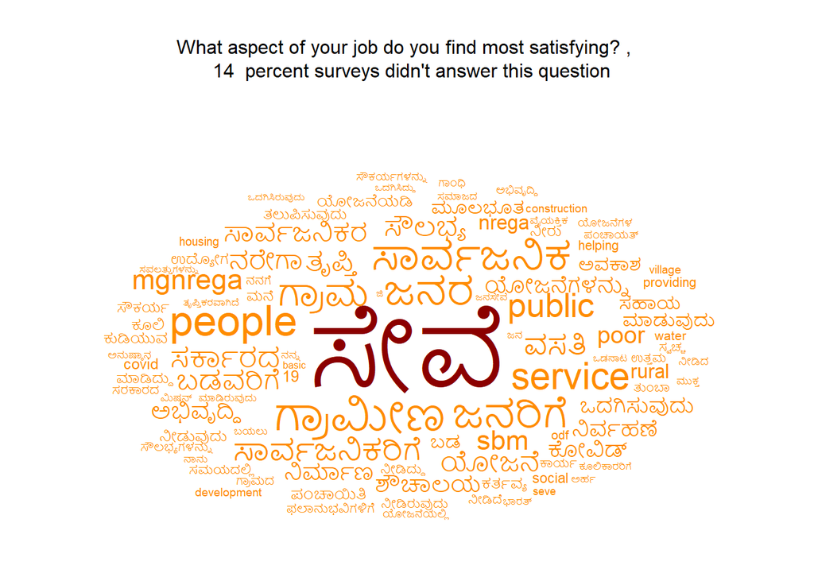

### Translated

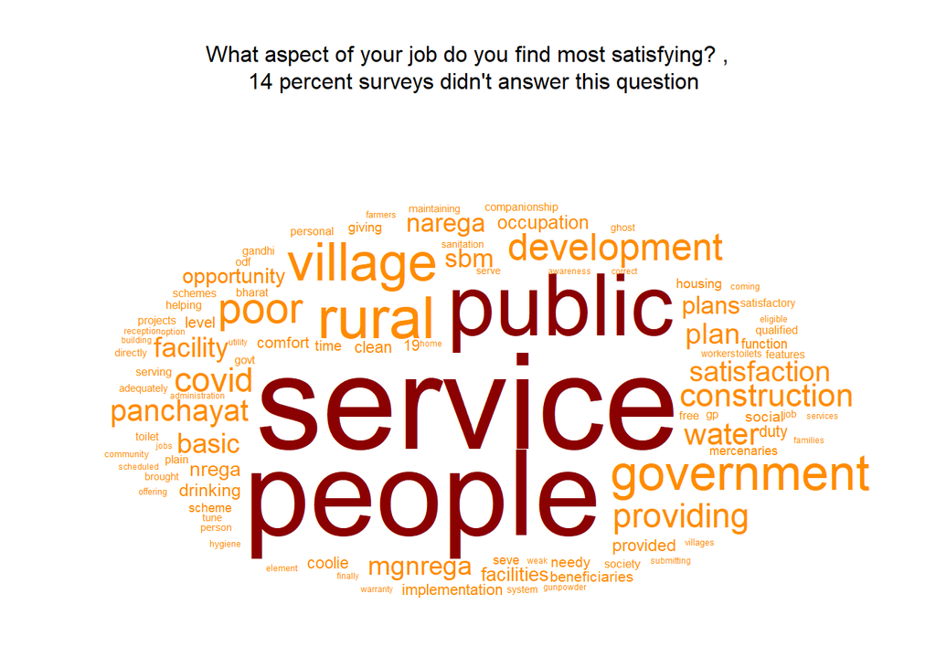

## What aspect of your job do you find most frustrating?

### Raw

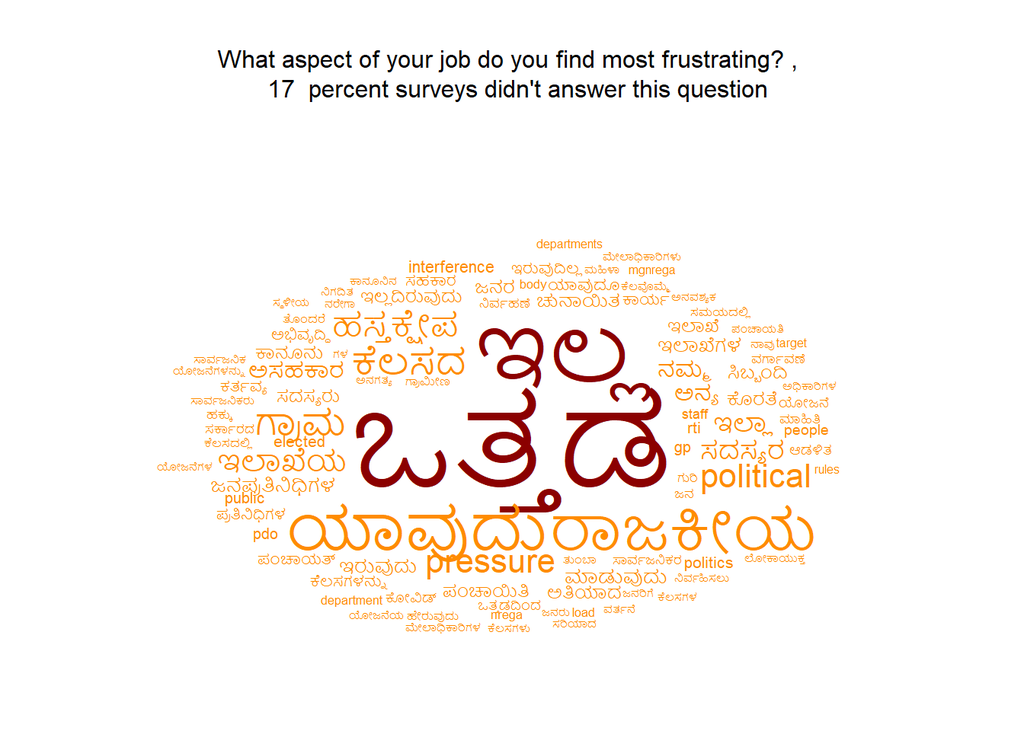

### Translated

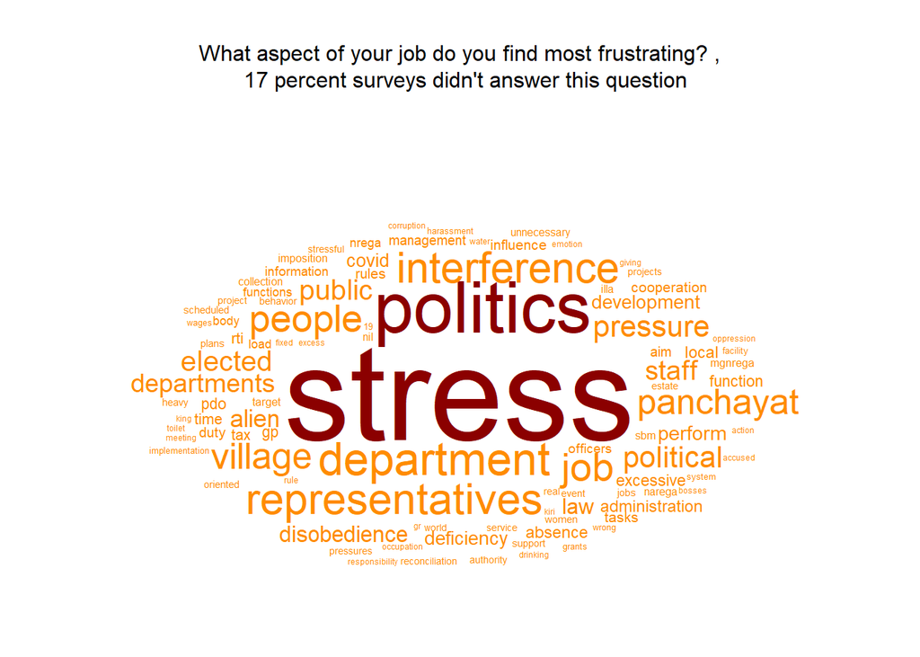

## In which areas would you appreciate more support from the RDPR Department?

### Raw

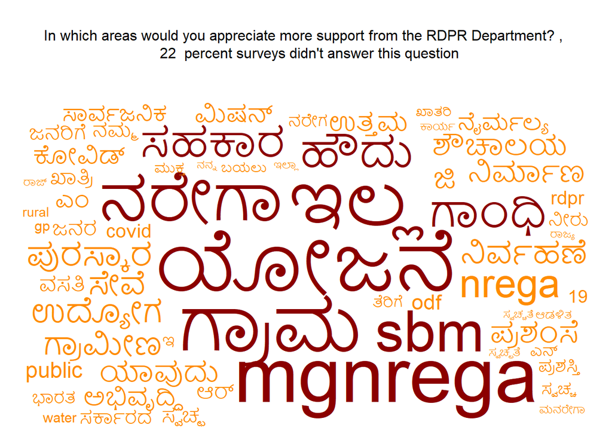

### Translated

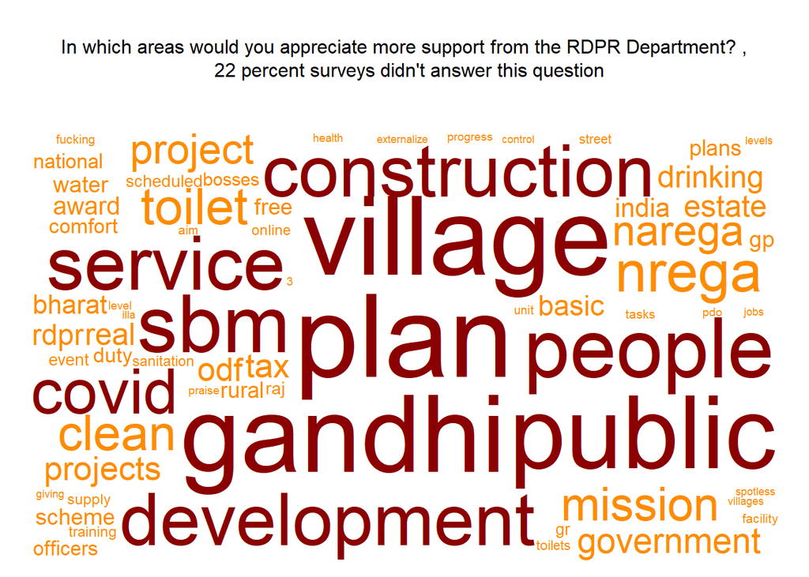

## Another area of responsibility on which you spent a significant amount of time,

### Raw

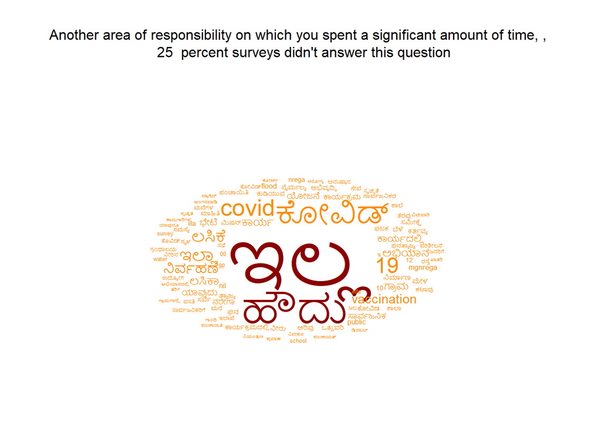

### Translated

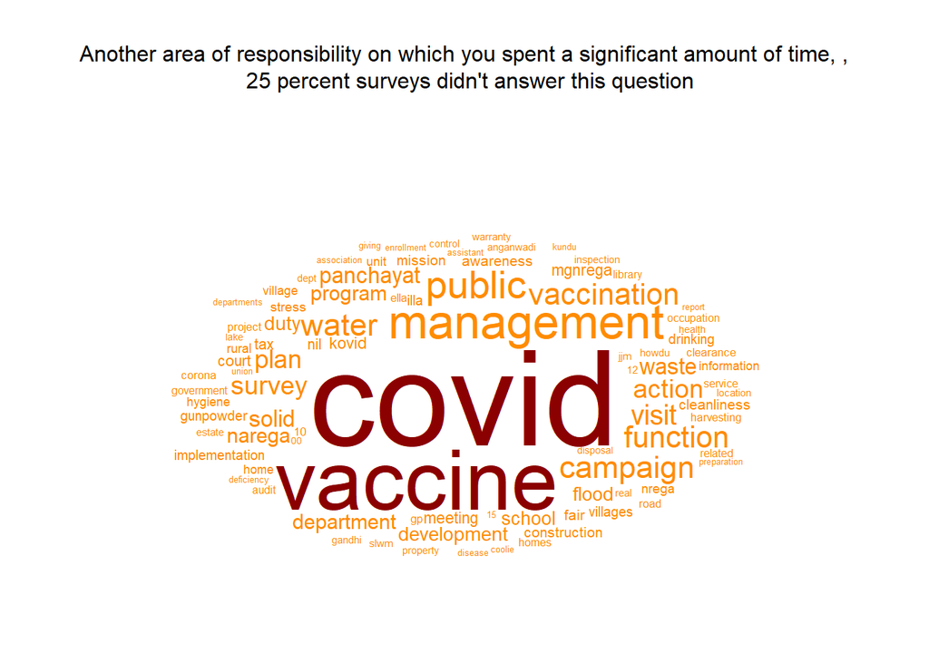

## What was a task that took up much more of your time than you expected?

### Raw

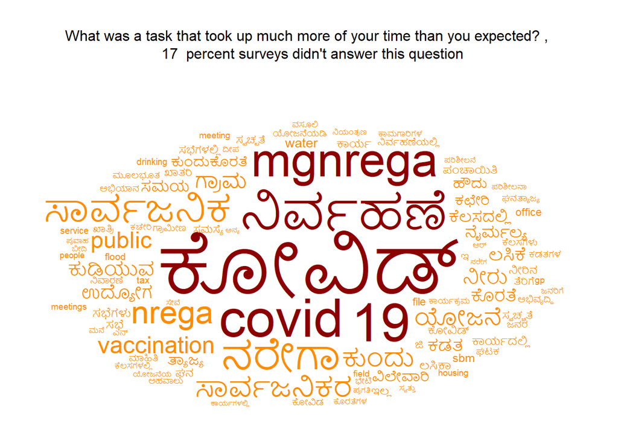

### Translated

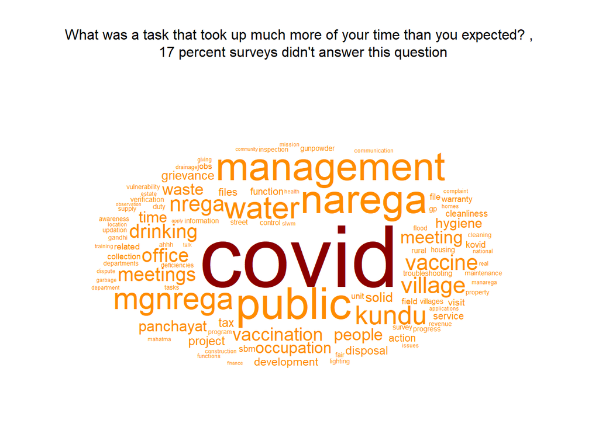

## What can be done to help you do your work more effectively?

### Raw

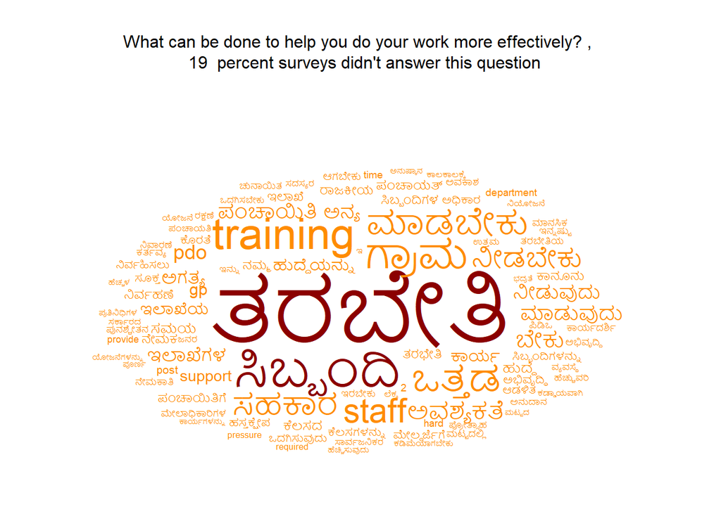

### Translated

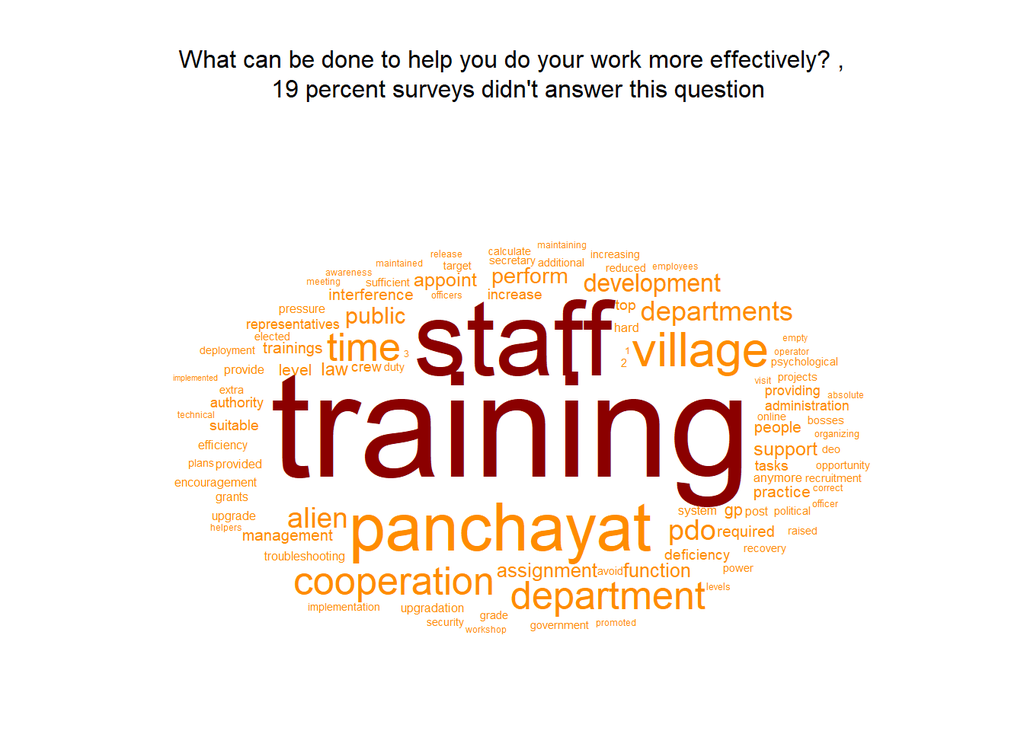

### Raw

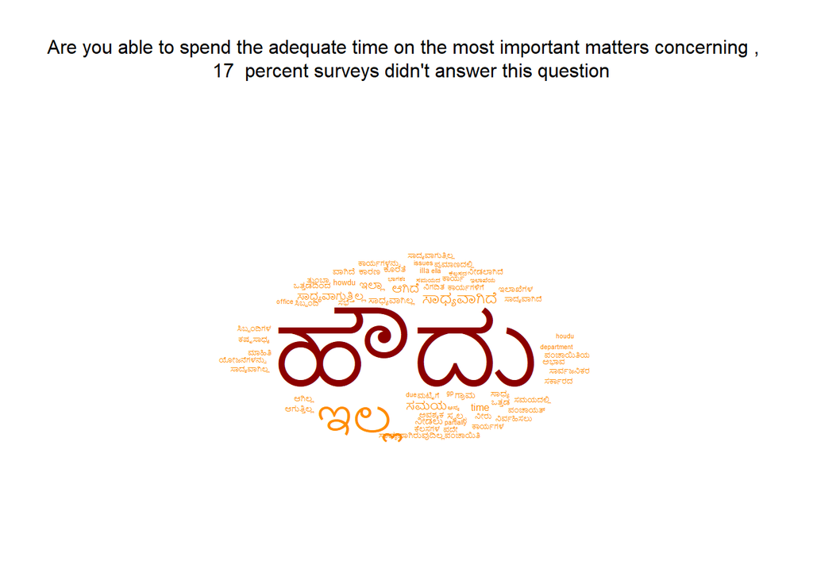

### Translated

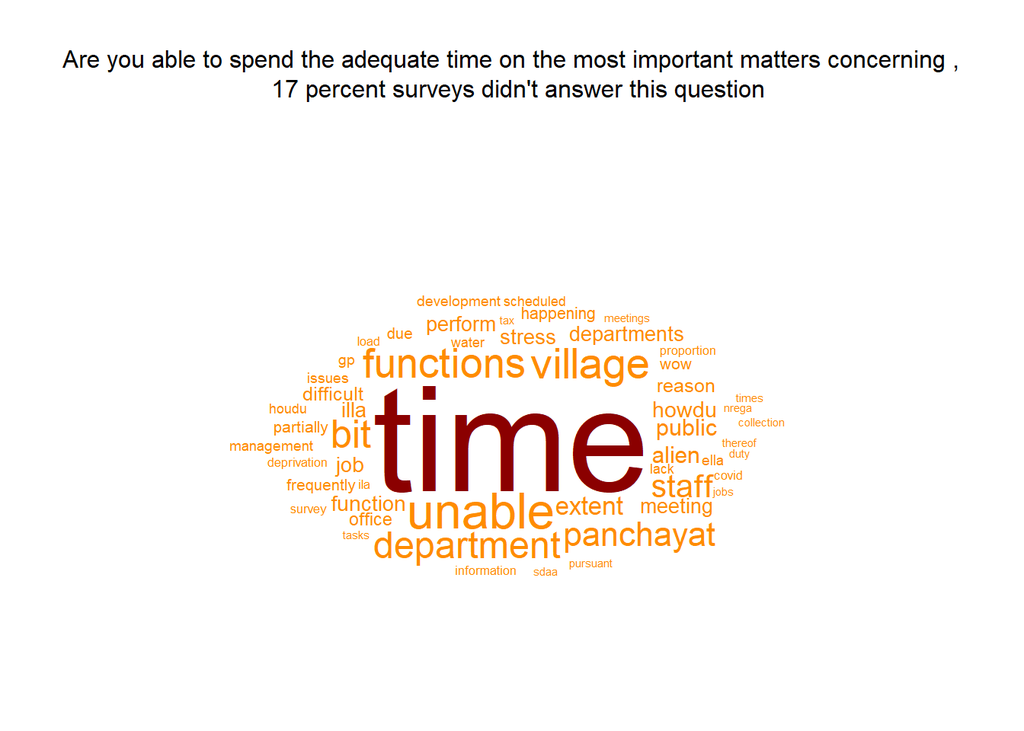

## What work did the COVID taskforce/warriors do in your gram panchayat?

### Raw

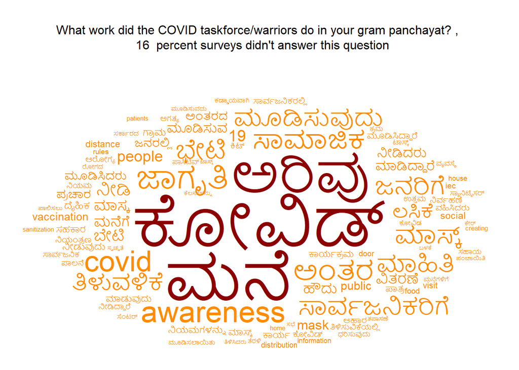

### Translated

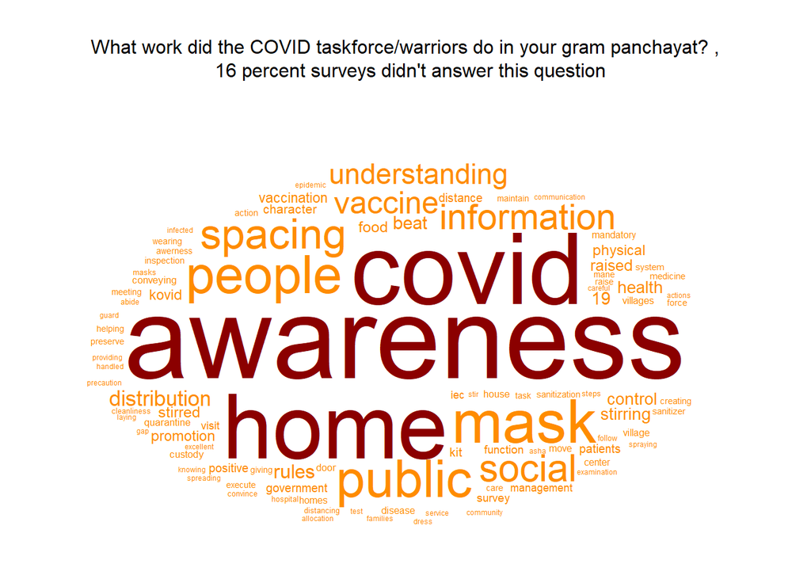

## What challenges did you face in managing COVID?

### Raw

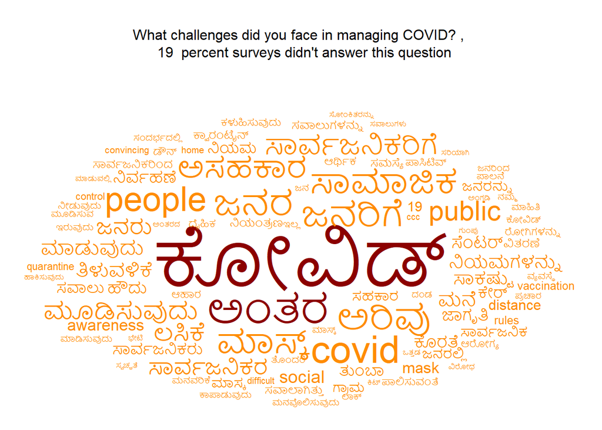

### Translated

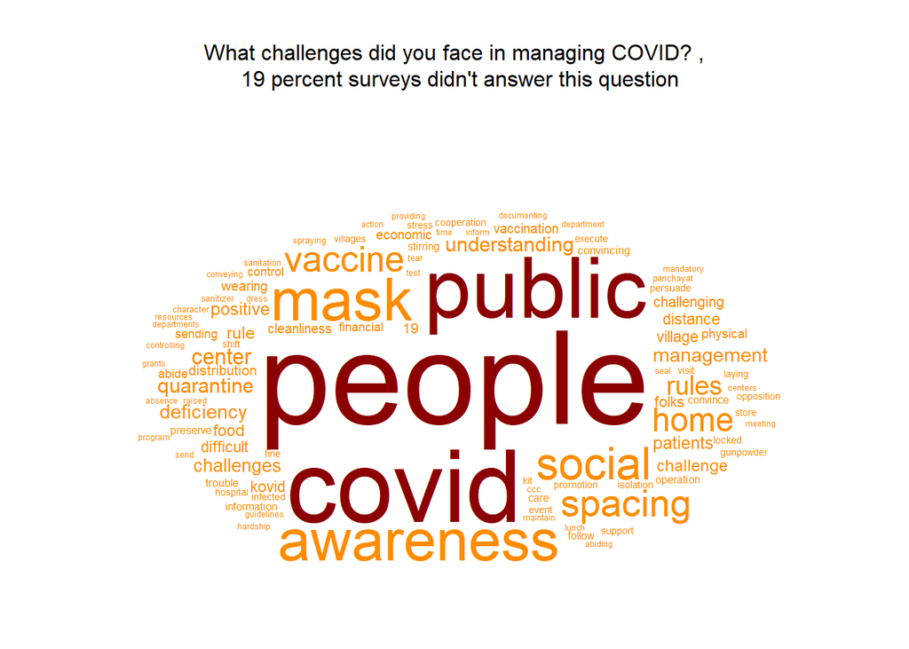

## What department support did you receive for COVID management?

### Raw

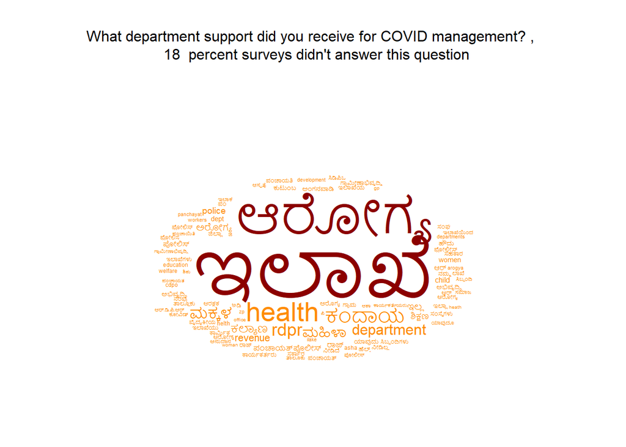

### Translated

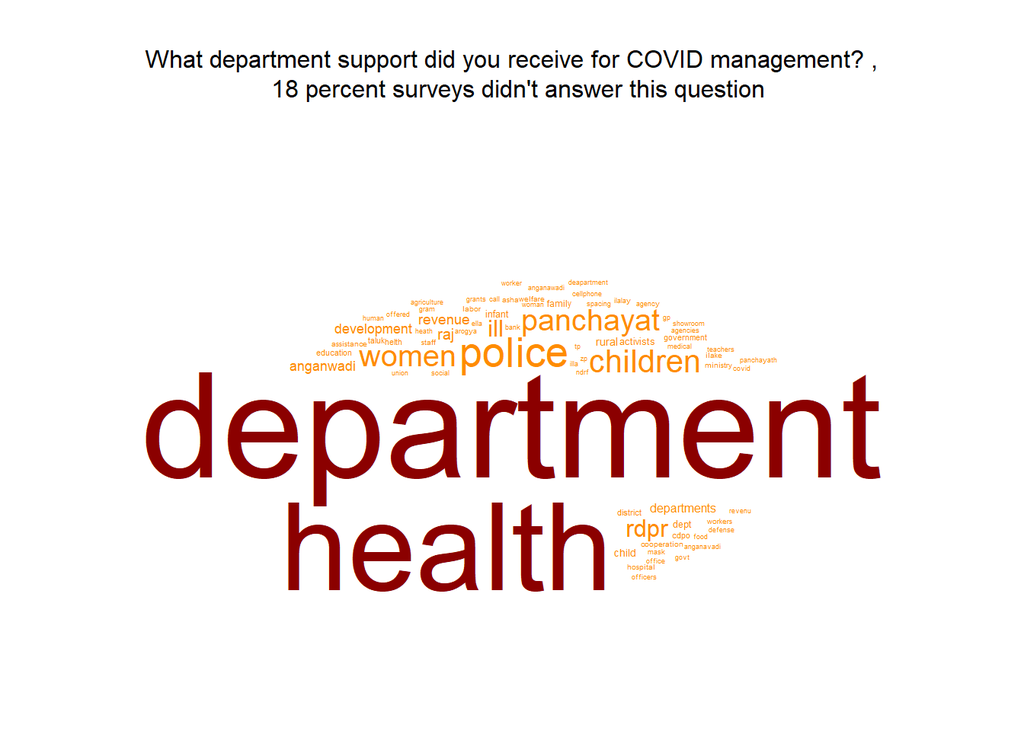

## What was the role of this person in COVID management?

### Raw

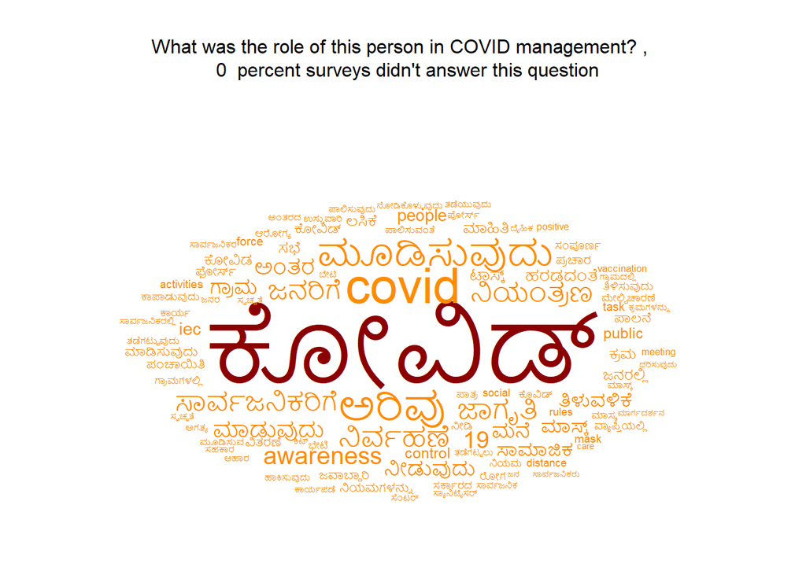

### Translated

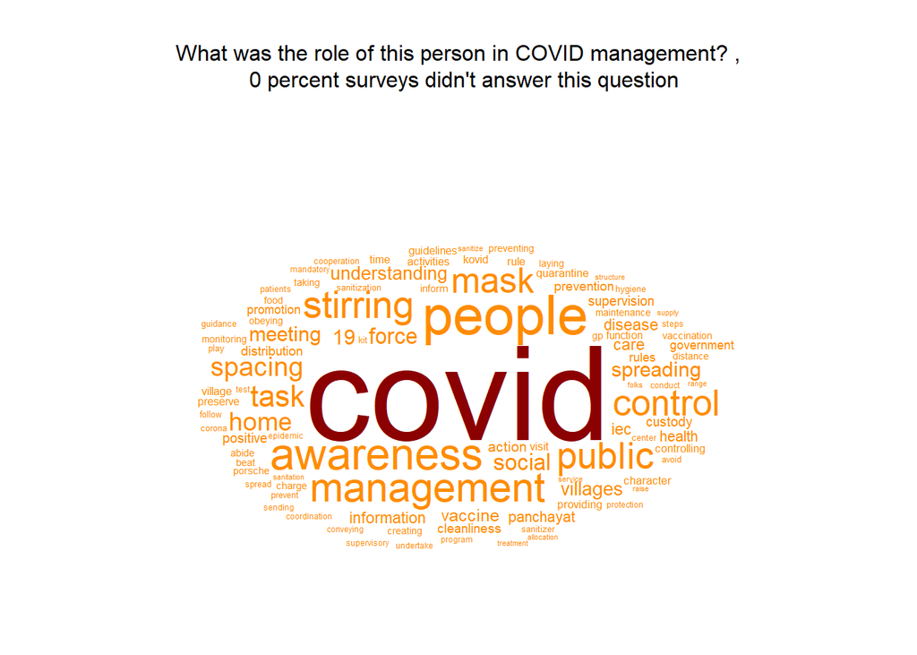

### Raw

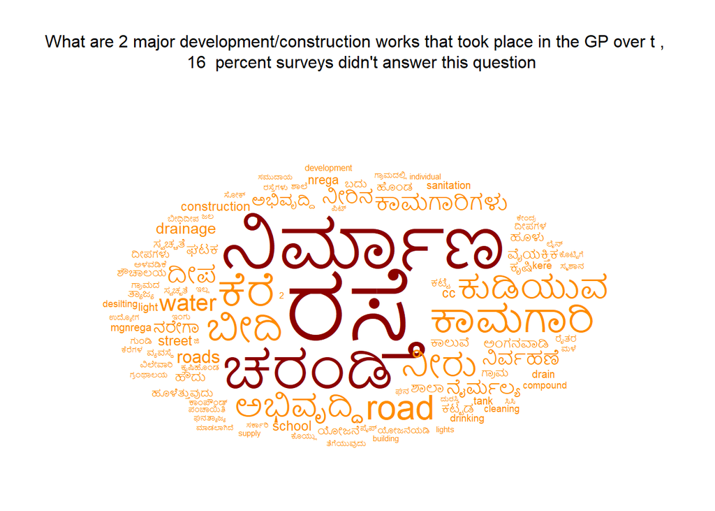

### Translated

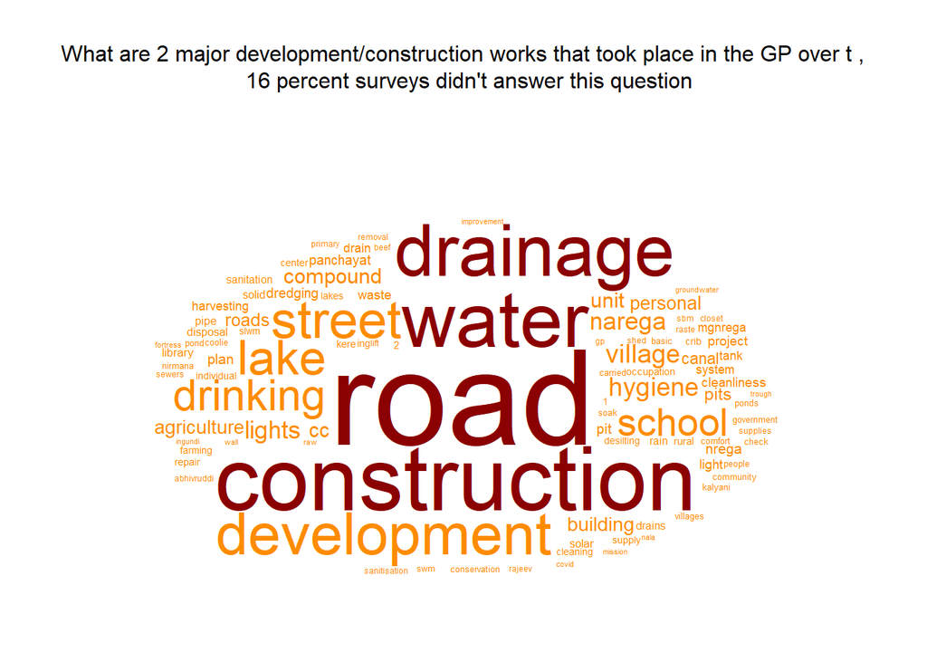

## How is COVID management different this year (2021) compared to last year (2020)?

### Raw

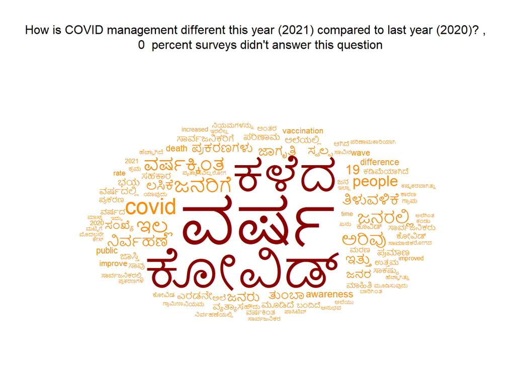

### Translated

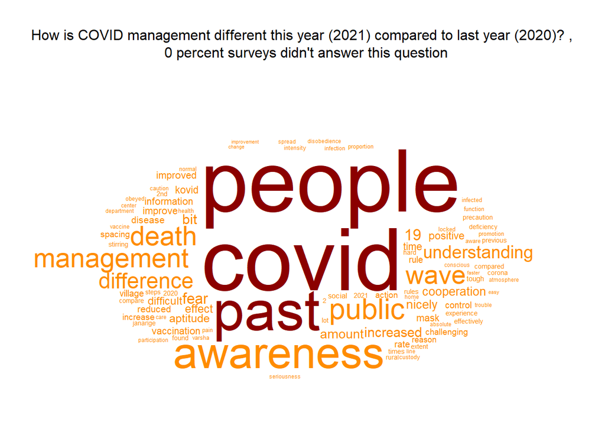

## What are some of the notable events that took place in the GP over the past year

### Raw

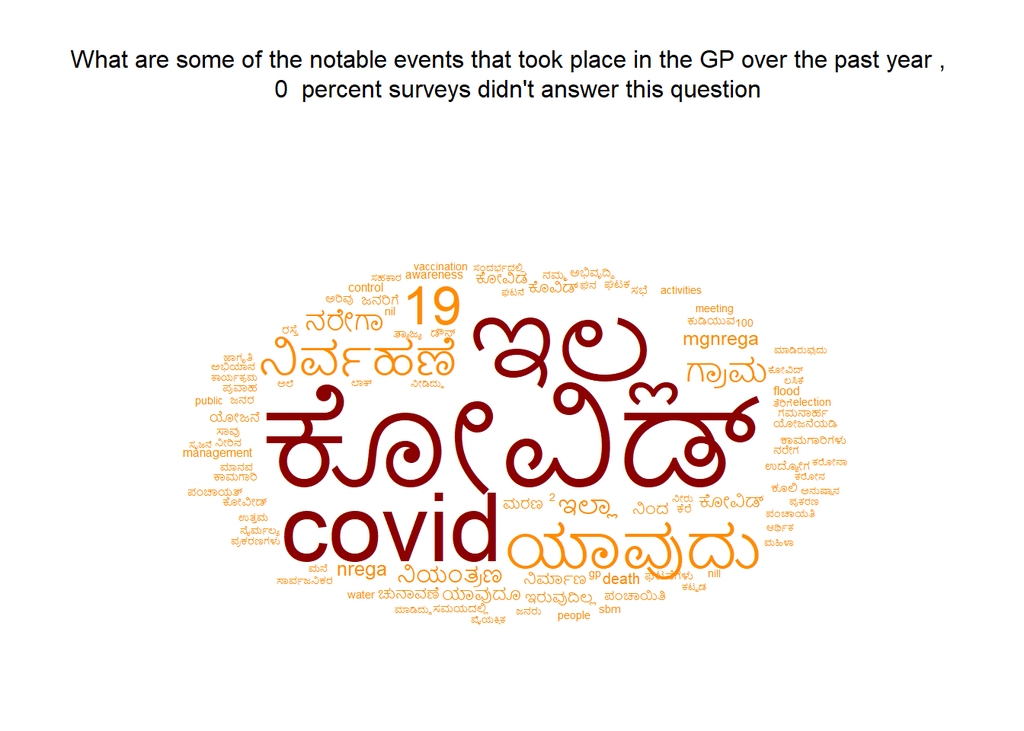

### Translated

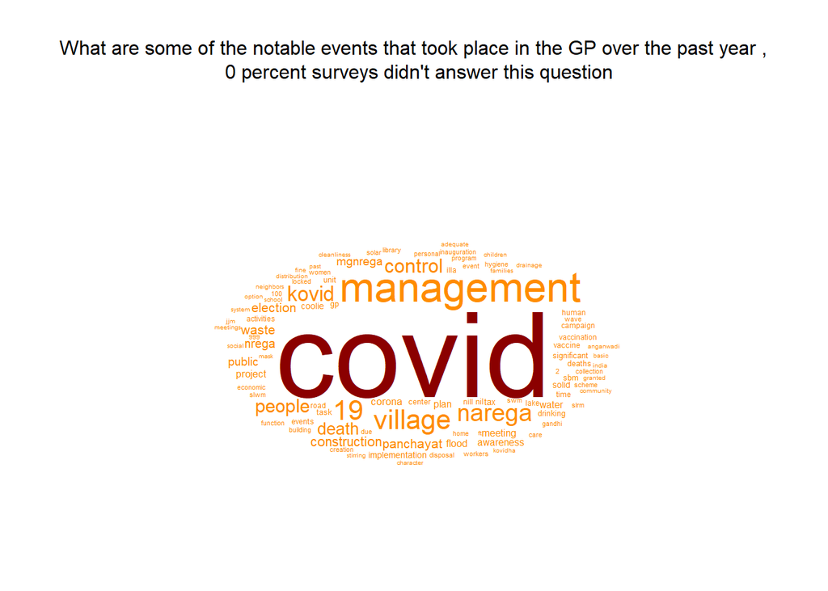

### Raw

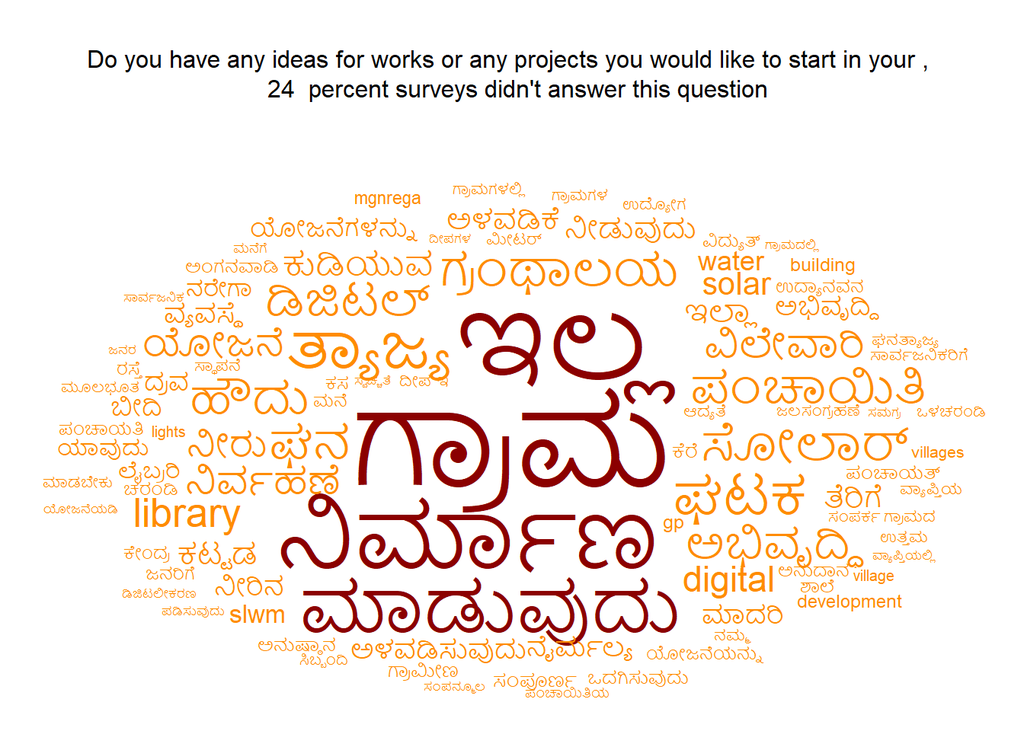

### Translated

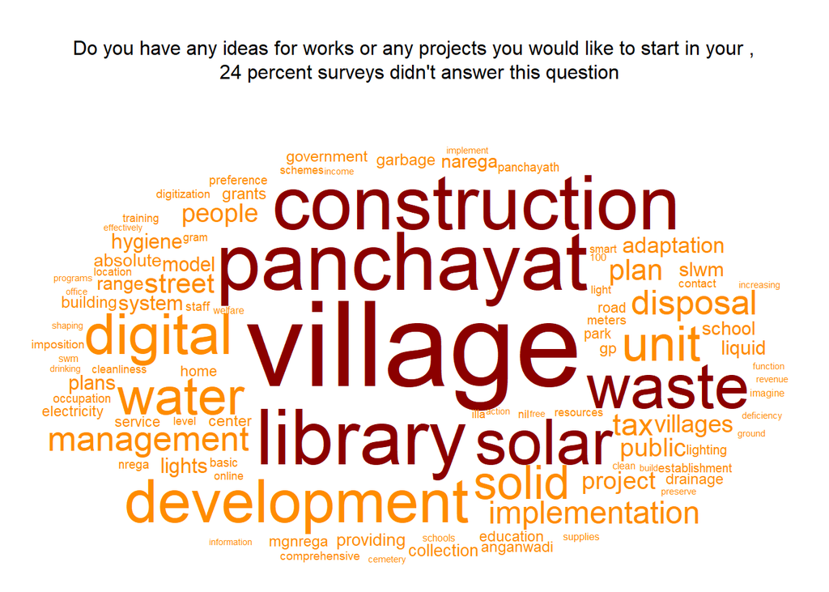

### Raw

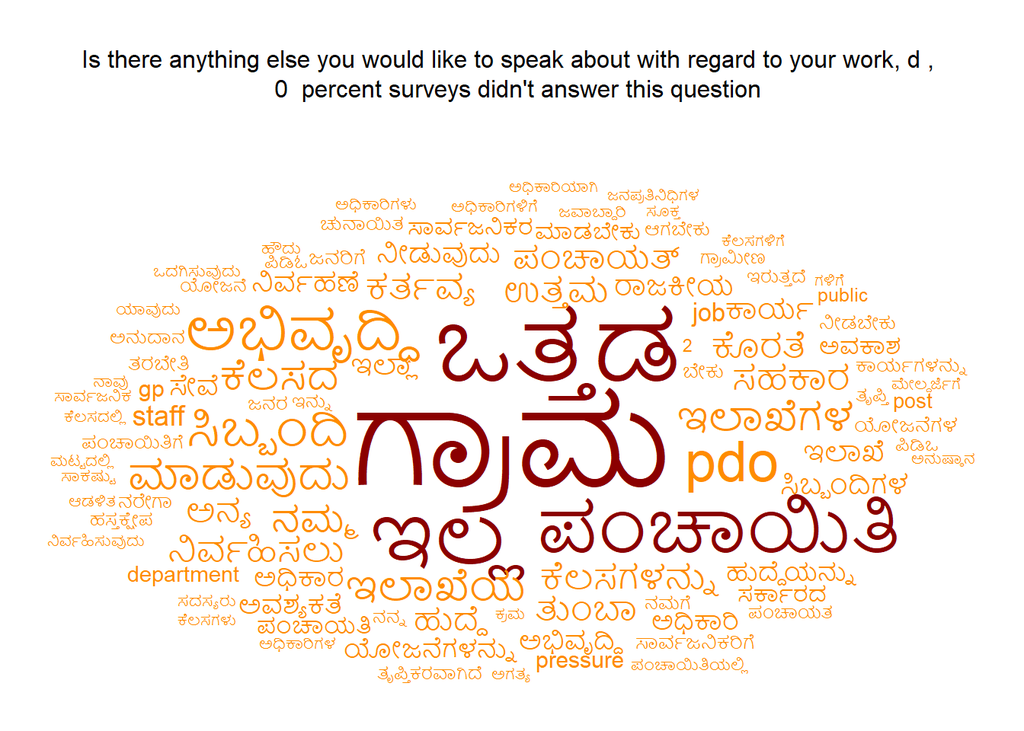

### Translated

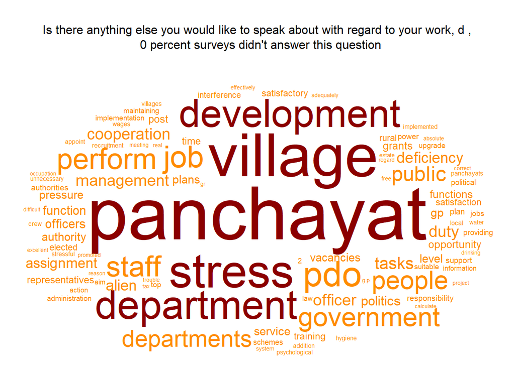